# Naive Bayes aplicado al dataset Iris

Alferry

2025-07-02

## Introduccion

Este documento explica y aplica el algoritmo **Naive Bayes** al conjunto de datos **Iris**, usando el paquete `e1071` de R. Naive Bayes es un clasificador probabilistico basado en el **Teorema de Bayes**, que asume independencia condicional entre los atributos dado la clase:

$$P(y \mid x_1, \dots, x_n) = \frac{P(y)
\prod_{i=1}^{n} P(x_i \mid y)}{P(x_1, \dots, x_n)}$$

Para clasificar una nueva observacion, el modelo calcula la probabilidad posterior de cada clase y elige la de mayor valor (regla de decision MAP).

En el caso de atributos numericos continuos (como los de Iris), `e1071::naiveBayes` asume que, dentro de cada clase, cada atributo sigue una **distribucion normal**, estimando la media y varianza de cada atributo por clase a partir de los datos de entrenamiento.

## Cargar paquetes y datos

```r
library(e1071)    # Contiene la funcion naiveBayes
library(caret)    # Para particion y evaluacion del modelo
```

```r
library(ggplot2)  # Para visualizacion

data(iris)
str(iris)
```

```
## 'data.frame':    150 obs. of  5 variables:
##  $ Sepal.Length: num  5.1 4.9 4.7 4.6 5 5.4 4.6 5 4.4 4.9 ...
##  $ Sepal.Width : num  3.5 3 3.2 3.1 3.6 3.9 3.4 3.4 2.9 3.1 ...
##  $ Petal.Length: num  1.4 1.4 1.3 1.5 1.4 1.7 1.4 1.5 1.4 1.5 ...
##  $ Petal.Width : num  0.2 0.2 0.2 0.2 0.2 0.4 0.3 0.2 0.2 0.1 ...
##  $ Species     : Factor w/ 3 levels "setosa","versicolor",..: 1 1 1 1 1 1 1 1 1 1 ...
```

```r
head(iris)
```

|  | Sepal.Length | Sepal.Width | Petal.Length | Petal.Width | Species |
| --- | --- | --- | --- | --- | --- |
| 1 | 5.1 | 3.5 | 1.4 | 0.2 | setosa |
| 2 | 4.9 | 3.0 | 1.4 | 0.2 | setosa |
| 3 | 4.7 | 3.2 | 1.3 | 0.2 | setosa |
| 4 | 4.6 | 3.1 | 1.5 | 0.2 | setosa |
| 5 | 5.0 | 3.6 | 1.4 | 0.2 | setosa |
| 6 | 5.4 | 3.9 | 1.7 | 0.4 | setosa |

```r
summary(iris)
```

```
##   Sepal.Length    Sepal.Width     Petal.Length    Petal.Width
##  Min.   :4.300   Min.   :2.000   Min.   :1.000   Min.   :0.100
##  1st Qu.:5.100   1st Qu.:2.800   1st Qu.:1.600   1st Qu.:0.300
##  Median :5.800   Median :3.000   Median :4.350   Median :1.300
##  Mean   :5.843   Mean   :3.057   Mean   :3.758   Mean   :1.199
##  3rd Qu.:6.400   3rd Qu.:3.300   3rd Qu.:5.100   3rd Qu.:1.800
##  Max.   :7.900   Max.   :4.400   Max.   :6.900   Max.   :2.500
##        Species
##  setosa    :50
##  versicolor:50
##  virginica :50
##
##
##
```

```r
sum(is.na(iris))       # Verificar valores faltantes
```

```
## [1] 0
```

```r
table(iris$Species)    # Distribucion de clases (50 por especie)
```

```
##
##     setosa versicolor  virginica
##         50         50         50
```

## Analisis exploratorio

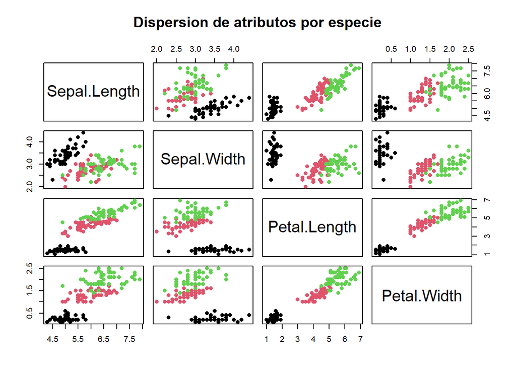

```r
pairs(iris[,1:4], col = iris$Species, pch = 16,
      main = "Dispersion de atributos por especie")
```

Se observa que `Petal.Length` y `Petal.Width` separan muy claramente a `setosa` del resto, mientras que `versicolor` y `virginica` se solapan mas.

## Particion entrenamiento / prueba

```r
set.seed(123)
train_index <- createDataPartition(iris$Species, p = 0.7, list = FALSE)
train_data <- iris[train_index, ]
test_data  <- iris[-train_index, ]

dim(train_data)
```

```
## [1] 105   5
```

```r
dim(test_data)
```

```
## [1] 45  5
```

## Entrenamiento del modelo

```r
modelo_nb <- naiveBayes(Species ~ ., data = train_data)
print(modelo_nb)
```

```
##
## Naive Bayes Classifier for Discrete Predictors
##
## Call:
## naiveBayes.default(x = X, y = Y, laplace = laplace)
##
## A-priori probabilities:
## Y
##     setosa versicolor  virginica
##  0.3333333  0.3333333  0.3333333
##
## Conditional probabilities:
##             Sepal.Length
## Y                [,1]      [,2]
##   setosa     4.991429 0.3657156
##   versicolor 5.942857 0.4558674
##   virginica  6.631429 0.6846087
##
##             Sepal.Width
## Y                [,1]      [,2]
##   setosa     3.365714 0.3455114
##   versicolor 2.777143 0.3227508
##   virginica  2.982857 0.3222035
##
##             Petal.Length
## Y                [,1]      [,2]
##   setosa     1.471429 0.1808012
##   versicolor 4.262857 0.4222389
##   virginica  5.591429 0.5741344
##
##             Petal.Width
## Y                 [,1]       [,2]
##   setosa     0.2314286 0.09321521
##   versicolor 1.3285714 0.20518489
##   virginica  2.0342857 0.25775371
```

```r
# Probabilidades a priori de cada clase
modelo_nb$apriori
```

```
## Y
##     setosa versicolor  virginica
##         35         35         35
```

```r
# Medias y desviaciones estandar por atributo y clase
modelo_nb$tables
```

```
## $Sepal.Length
##             Sepal.Length
## Y                [,1]      [,2]
##   setosa     4.991429 0.3657156
##   versicolor 5.942857 0.4558674
##   virginica  6.631429 0.6846087
##
## $Sepal.Width
##             Sepal.Width
## Y                [,1]      [,2]
##   setosa     3.365714 0.3455114
##   versicolor 2.777143 0.3227508
##   virginica  2.982857 0.3222035
##
## $Petal.Length
##             Petal.Length
## Y                [,1]      [,2]
##   setosa     1.471429 0.1808012
##   versicolor 4.262857 0.4222389
##   virginica  5.591429 0.5741344
##
## $Petal.Width
##             Petal.Width
## Y                 [,1]       [,2]
##   setosa     0.2314286 0.09321521
##   versicolor 1.3285714 0.20518489
##   virginica  2.0342857 0.25775371
```

## Prediccion sobre el conjunto de prueba

```r
predicciones <- predict(modelo_nb, test_data)
predicciones
```

```
##  [1] setosa     setosa     setosa     setosa     setosa     setosa
##  [7] setosa     setosa     setosa     setosa     setosa     setosa
## [13] setosa     setosa     setosa     versicolor virginica  versicolor
## [19] versicolor versicolor versicolor virginica  versicolor versicolor
## [25] versicolor versicolor versicolor versicolor versicolor versicolor
## [31] virginica  virginica  virginica  virginica  virginica  virginica
## [37] versicolor virginica  virginica  virginica  versicolor virginica
## [43] virginica  virginica  virginica
## Levels: setosa versicolor virginica
```

```r
test_data$Species
```

```
##  [1] setosa     setosa     setosa     setosa     setosa     setosa
##  [7] setosa     setosa     setosa     setosa     setosa     setosa
## [13] setosa     setosa     setosa     versicolor versicolor versicolor
## [19] versicolor versicolor versicolor versicolor versicolor versicolor
## [25] versicolor versicolor versicolor versicolor versicolor versicolor
## [31] virginica  virginica  virginica  virginica  virginica  virginica
## [37] virginica  virginica  virginica  virginica  virginica  virginica
## [43] virginica  virginica  virginica
## Levels: setosa versicolor virginica
```

## Matriz de confusion y exactitud

```r
matriz_confusion <- confusionMatrix(predicciones, test_data$Species)
matriz_confusion
```

```
## Confusion Matrix and Statistics
##
##             Reference
## Prediction   setosa versicolor virginica
##   setosa         15          0         0
##   versicolor      0         13         2
##   virginica       0          2        13
##
## Overall Statistics
##
##                Accuracy : 0.9111
##                  95% CI : (0.7878, 0.9752)
##     No Information Rate : 0.3333
##     P-Value [Acc > NIR] : 8.467e-16
##
##                   Kappa : 0.8667
##
##  Mcnemar's Test P-Value : NA
##
## Statistics by Class:
##
##                      Class: setosa Class: versicolor Class: virginica
## Sensitivity                 1.0000            0.8667           0.8667
## Specificity                 1.0000            0.9333           0.9333
## Pos Pred Value              1.0000            0.8667           0.8667
## Neg Pred Value              1.0000            0.9333           0.9333
## Prevalence                  0.3333            0.3333           0.3333
## Detection Rate              0.3333            0.2889           0.2889
## Detection Prevalence        0.3333            0.3333           0.3333
## Balanced Accuracy           1.0000            0.9000           0.9000
```

## Prediccion de observaciones nuevas

```r
nuevos_datos <- data.frame(
  Sepal.Length = c(5.1, 6.7, 5.8),
  Sepal.Width  = c(3.5, 3.0, 2.7),
  Petal.Length = c(1.4, 5.2, 4.2),
  Petal.Width  = c(0.2, 2.3, 1.3)
)
nuevos_datos
```

| Sepal.Length | Sepal.Width | Petal.Length | Petal.Width |
| --- | --- | --- | --- |
| 5.1 | 3.5 | 1.4 | 0.2 |
| 6.7 | 3.0 | 5.2 | 2.3 |
| 5.8 | 2.7 | 4.2 | 1.3 |

```r
nuevas_predicciones <- predict(modelo_nb, nuevos_datos)
nuevas_predicciones
```

```
## [1] setosa     virginica  versicolor
## Levels: setosa versicolor virginica
```

```r
probabilidades <- predict(modelo_nb, nuevos_datos, type = "raw")
probabilidades
```

```
##             setosa   versicolor    virginica
## [1,]  1.000000e+00 8.913737e-20 5.114392e-26
## [2,] 1.785606e-203 1.268812e-06 9.999987e-01
## [3,]  9.123989e-80 9.998715e-01 1.285303e-04
```